# Task 2: Agglomerative hierarchical clustering

Pol Carbó Mestre

February 15, 2022

```r
knitr::opts_chunk$set(echo = TRUE, message = F, warning = F)
```

# Overview

This task will use hierarchical clustering using complete linkage method to create a dendrogram showing multivariate clustering for water chemistry between different locations. The data used contains stream water chemistry measurements taken in Santa Barbara area watersheds from 2000 to 2018. The variables sampled in the SBC LTER watersheds include: Dissolved nitrogen (nitrate, ammonium, total dissolved nitrogen). Soluble reactive phosphorus (SRP). Particulate organic carbon, nitrogen and phosphorus. Total suspended sediments. Conductivity. The goal is to evaluate potential clustering of observations by location, based on the average measurements per site, and see whether we can identify patterns/natural groups among the measurement stations.

**Data source**: Citation: Santa Barbara Coastal LTER and J. Melack. 2019. SBC LTER: Land: Stream chemistry in the Santa Barbara Coastal drainage area, ongoing since 2000 ver 16. Environmental Data Initiative. https://doi.org/10.6073/pasta/67a558a24ceed9a0a5bf5e46ab841174.

```r
df <- read_csv(here("data","sbc_lter_registered_stream_chemistry.csv"), na = "-999")
```

# Data reading and wrangling

To perform hierarchical clustering by site, we will first get a summary based on means from all observations at a specific site. Then we will calculate the Euclidean distance before performing the complete linkage agglomerative hierarchical clustering. Since the variables show a high disparity of ranges regarding their scales, we will scale the numerical variables.

```r
df1 <- df %>%
  group_by(site_code) %>%
  summarise_at(colnames(df)[c(-1,-2)], mean, na.rm = TRUE) %>% # compute mean values
  data.frame() %>%
  set_rownames(.$site_code) %>% # Set site_code as rownames
  select(-1) %>%
  scale() # Scale the data

kable(df1,
      booktabs = T,
      digits=1,
      caption = "Table 1. Data of interest") %>%
  kable_styling(c("striped", "hover"),full_width = FALSE,font_size = 10) %>%
  column_spec(1, bold = T)
```

Table 1. Data of interest

|  | nh4_uM | no3_uM | po4_uM | tdn_uM | tdp_uM | tpc_uM | tpn_uM | tpp_uM | tss_mgperLiter | spec_cond_uSpercm |
| --- | --- | --- | --- | --- | --- | --- | --- | --- | --- | --- |
| AB00 | -0.1 | -0.5 | 0.2 | -0.4 | 0.6 | -0.5 | -0.5 | 0.0 | -0.8 | -0.3 |
| AT07 | -0.3 | -0.4 | 1.7 | -0.3 | 1.3 | -0.7 | -0.7 | -0.6 | -1.0 | -0.1 |
| BC02 | -0.3 | 2.7 | 0.4 | 3.0 | 0.0 | NaN | NaN | NaN | 0.9 | 1.0 |
| DV01 | 3.1 | -0.3 | 2.1 | 0.0 | 2.2 | NaN | NaN | NaN | -1.1 | 2.7 |
| GV01 | 0.1 | -0.8 | 0.0 | -0.7 | -0.1 | 0.7 | 0.6 | 2.2 | 0.3 | 0.2 |
| HO00 | -0.7 | -0.6 | -1.3 | -0.9 | -1.0 | -0.7 | -0.7 | -0.6 | -1.0 | -0.6 |
| MC00 | 0.1 | -0.5 | 0.3 | -0.3 | 0.4 | -0.6 | -0.6 | -0.6 | -0.6 | -1.0 |
| MC06 | -0.6 | -0.5 | -0.2 | -0.4 | 0.1 | -0.6 | -0.6 | -0.6 | 0.0 | -0.1 |
| ON02 | 0.5 | 0.0 | -0.8 | -0.1 | -1.1 | 2.2 | 2.1 | 1.1 | 2.3 | -0.7 |
| RG01 | -0.4 | 0.1 | -0.5 | 0.0 | -0.6 | -0.5 | -0.5 | -0.3 | 0.2 | 0.6 |
| RS02 | -0.4 | -0.6 | -0.9 | -0.7 | -0.9 | 0.5 | 1.0 | -0.6 | 0.7 | -0.9 |
| SP02 | -0.3 | -0.2 | 0.0 | -0.2 | 0.2 | NaN | NaN | NaN | 0.1 | -0.8 |
| TO02 | -0.7 | 1.5 | -1.0 | 0.9 | -1.1 | NaN | NaN | NaN | NaN | 0.0 |

# Hierarchical clustering

## Euclidean distances

Once we have a simplified, scaled version of the numeric variables, with row names containing the site code, we can calculate the Euclidean distances that we will use to construct the dendrogram.

```r
df_dist <- dist(df1, method = 'euclidean')
(round(df_dist,2))
```

```
##      AB00 AT07 BC02 DV01 GV01 HO00 MC00 MC06 ON02 RG01 RS02 SP02
## AT07 1.79
## BC02 6.19 6.42
## DV01 6.05 5.38 7.90
## GV01 3.14 4.31 6.19 6.27
## HO00 2.40 3.82 7.14 8.25 4.12
## MC00 1.02 1.96 6.33 6.47 3.70 2.43
## MC06 1.35 2.53 5.89 6.89 3.46 1.93 1.49
## ON02 5.52 6.63 5.95 8.43 3.69 5.72 5.56 5.23
## RG01 2.16 3.36 5.04 6.93 3.39 2.19 2.46 1.37 4.87
## RS02 3.19 4.47 6.60 8.32 3.39 2.72 3.05 2.58 3.37 2.67
## SP02 1.49 2.89 5.69 6.95 1.68 2.68 1.17 1.11 3.40 2.16 2.06
## TO02 4.22 5.55 4.07 8.76 4.19 3.70 4.41 3.66 2.92 2.50 3.66 3.63
```

## By complete linkage

Complete-linkage (farthest neighbor) distances are measured between two clusters’ most distant pair of observations. Using the computed dissimilarity matrix, we will perform hierarchical clustering using the function `hclust`, and specifying the method of interest, in this case, `complete`.

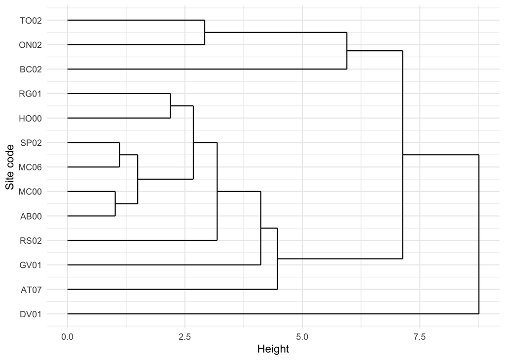

Figure 1. Hierarchical clustering by complete linkage.

```r
# Hierarchical clustering (complete linkage)
hc_complete <- hclust(df_dist, method = "complete" )

ggdendrogram(hc_complete,
             rotate = TRUE) +
  theme_minimal() +
  labs( x = "Site code",
        y = "Height") +
  theme(legend.position = "bottom",
        legend.title = element_blank(),
        plot.caption = element_textbox_simple(margin = margin(10,0,0,0)),
        plot.caption.position = "plot")
```

## By single linkage

Single-linkage (nearest neighbor) is the shortest distance between a pair of observations in two clusters. This time we will use the same function specifying `method="single"`.

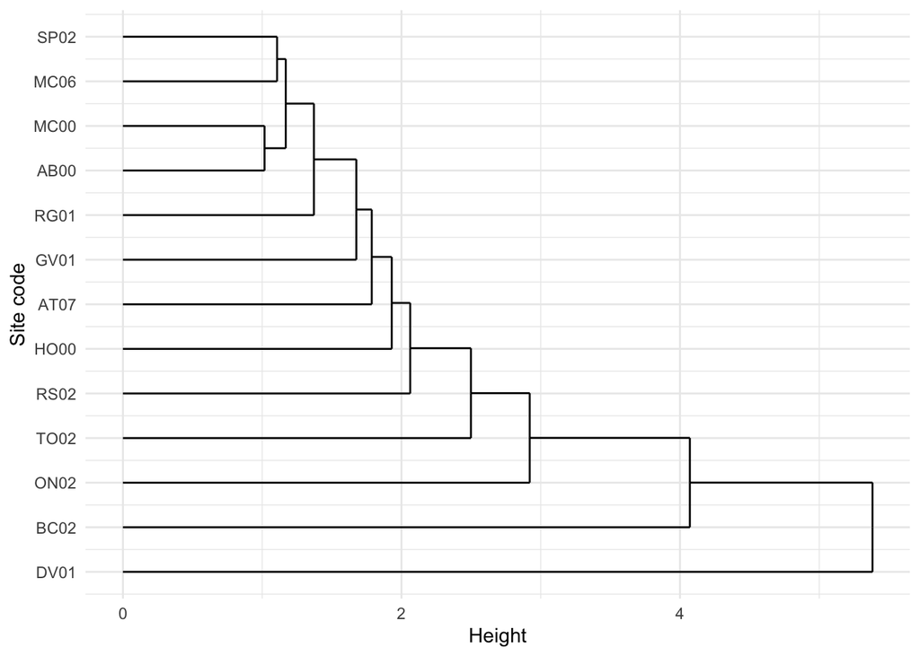

Figure 2. Hierarchical clustering by single linkage.

```r
# Hierarchical clustering (single linkage)
hc_single <- hclust(df_dist, method = "single" )


ggdendrogram(hc_single,
             rotate = TRUE) +
  theme_minimal() +
  labs( x = "Site code",
        y = "Height") +
  theme(legend.position = "bottom",
        legend.title = element_blank(),
        plot.caption = element_textbox_simple(margin = margin(10,0,0,0)),
        plot.caption.position = "plot")
```

## Comparison

Comparing both dendrograms through a tanglegram shows how the complete linkage method produces tighter clusters than the single-linkage, where the groups appear to spread out.

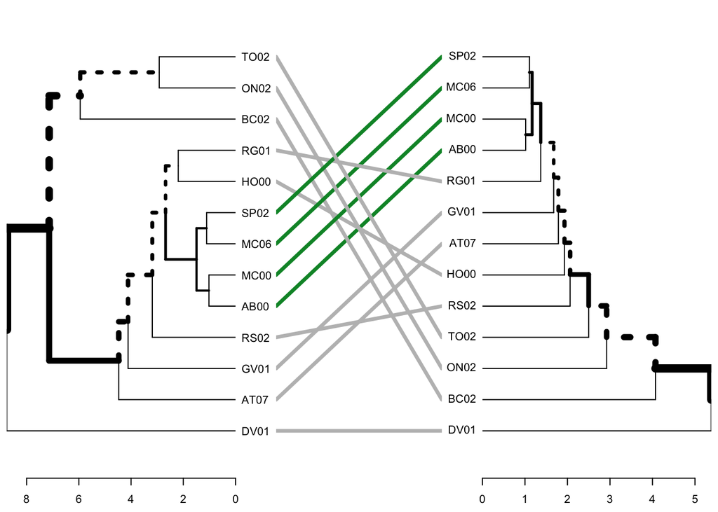

Figure 3. Tanglegram to compare complete and single linkage hierarchies.

```r
# Convert to class dendrogram
dend_complete <- as.dendrogram(hc_complete)
dend_simple <- as.dendrogram(hc_single)
# Make a tanglegram
tanglegram(dend_complete, dend_simple)
```

# Summary

- Using complete linkage, we can see how the sites have naturally been grouped in 2 well defined clusters, with location DV01 out of them.
- The biggest cluster is divided into two subclusters and three independent sites related.
- This cluster structure is not detected using single linkage, although relative branch distances between sites are still quite similar.
- Only one identical cluster is defined in both methods.
- More information available about the sites where the samples were collected, such as geo-location, the drainage sub-basins, or other relevant data, may help us understand these natural groups and explain the existing differences in measurements.